# Explore covariates for modeling

Aidan Brushett

2025-02-22

# 0. Before you begin

Aidan Brushett M.Sc. Student University of Victoria  
School of Environmental Studies  
Email: aidanbrushett@uvic.ca

# 1. Set up workspace

## 1.1. Install packages

If you don’t already have the following packages installed, use the code below to install them.

```r
list.of.packages <- c("tidyverse", "sf", "ggplot2")
new.packages <- list.of.packages[!(list.of.packages %in% installed.packages()[,"Package"])]
if(length(new.packages)) install.packages(new.packages)
rm(new.packages, list.of.packages)
```

## 1.2. Load libraries

And a couple custom functions that can help with masking issues from package loading:

```r
rm(list=ls()) # clear environment

library(tidyverse) # data tidying, visualization, and much more; this will load all tidyverse packages, can see complete list using tidyverse_packages()
library(ggplot2) # pretty plots
library(sf) # spatial data
library(PerformanceAnalytics)

# These are functions that can sometimes get masked by other packages. Shouldn't be an issue and could be removed.
select <- dplyr::select
filter <- dplyr::filter
mutate <- dplyr::mutate
summarize <- dplyr::summarize
# Cheeky function that means "not in"
`%nin%` = Negate(`%in%`)
```

# 2. Import data

Import the covariates. We will join these to the proportional response variable now.

```r
covs <- read_csv("./data/processed/all_arrays_covariates_grouped.csv",
                 col_types = cols(array = col_character(),
                                  site = col_character(),
                                  .default = col_number())) %>%
  select(-camera)
```

Let’s read in the response variable that we’d like to model. We’ll start with monthly proportional presence-absence and append the covariate data. All this step accomplishes is left joining the covariates to the data so that we only consider sites that we are *actually* using in our analysis.

We will not need to re-do our covariate exploration for different response variables, since 1) the weekly metrics use the exact same set of sites, and 2) we have no temporally varying covariates. A daily, weekly, hourly, etc. response variable may change the selection of sites that we use, but we can cross that bridge if it comes to it.

```r
data <- read_csv("./data/processed/all_arrays_proportional_presence_monthly_clean.csv",
                 col_types = cols(array = col_character(),
                                  site = col_character(),
                                  .default = col_number())) %>%

  left_join(covs, by = c('site', 'array'))

# Check to make sure there is only one row per site. We do NOT want duplicates, if there are any it is likely due to the covariate file glitching out and you will want to go back and fix this in the previous scripts or re-extract the covs.
data %>% group_by(site) %>%

  summarize(n = n()) %>%

  arrange(desc(n))
```

```
## # A tibble: 589 × 2
##    site      n
##    <chr> <int>
##  1 CL_1      1
##  2 CL_10     1
##  3 CL_12     1
##  4 CL_13     1
##  5 CL_14     1
##  6 CL_15     1
##  7 CL_16     1
##  8 CL_17     1
##  9 CL_18     1
## 10 CL_19     1
## # ℹ 579 more rows
```

# 3. Create landscape-scale covariates

For now, we will create three covariates at the landscape scale that could plausibly mediate site-level relationships between snowshoe hares and habitat patches. These are:

- Mean proportional presence of coyotes
- Mean proportional presence of lynx
- Mean disturbance from *all* human features

```r
# Buffer sizes in the dataset
buffers <- seq(from=250, to=5000, by=250)

# Define the human feature keywords for the variables we want to combine
human_features <- c("osm_industrial", "harvest", "pipeline", "roads",
                    "seismic_lines", "wells", "seismic_lines_3D", "trails",
                    "transmission_lines")

# Loop through each buffer size. Sum the columns for each buffer and assign to a new column
for(buffer in buffers){

  cols <- paste0(human_features, "_", buffer)

  human_footprint <- rowSums(select(data, matches(cols)))

  data[[paste0("human_footprint_", buffer)]] <- human_footprint
}

# Clean up the helpers from the loop
rm(buffer, human_footprint, human_features, cols)

landscape_covs <- data %>%

  mutate(coyote_abundance = coyote / months_active,
         lynx_abundance = lynx / months_active) %>%

  group_by(array) %>%

  summarize(coyote_landscape = mean(coyote_abundance),
            lynx_landscape = mean(lynx_abundance),
            across(starts_with("human_footprint_"), mean, na.rm = TRUE), .groups = "drop") %>%

  rename_with(~ gsub("human_footprint_", "hf_landscape_", .))
```

Now let’s merge the landscape covariates onto our big ol’ dataframe for model fitting.

```r
data <- data %>%

  left_join(landscape_covs,
            by = 'array')
```

# 4. Export final dataframes.

## 4.1. Site shapefile with covariates

This is the first spot in our workflow where it feels reasonable to export the shapefile of sites, since we now have a beautifully merged dataframe of our camera sites AND their covariates, with no extra sites for which we have no data (or sites we are discarding for our analysis). We’ll save it to our geodatabase.

```r
all_sites_sf <- st_as_sf(data,
                        coords = c("easting_12n", "northing_12n"),
                        crs = 26912)

st_write(all_sites_sf,
         dsn = './maps/OSM_mapping.gdb',
         layer = "all_arrays_locations_covariates",
         driver = "OpenFileGDB", append = FALSE)
```

```
## Deleting layer `all_arrays_locations_covariates' using driver `OpenFileGDB'
## Writing layer `all_arrays_locations_covariates' to data source
##   `./maps/OSM_mapping.gdb' using driver `OpenFileGDB'
## Writing 589 features with 413 fields and geometry type Point.
```

```r
rm(all_sites_sf)
```

## 4.2. Dataframe with covariates

```r
write_csv(data, "./data/processed/all_arrays_proportional_presence_monthly_with_covariates.csv")
```

# 5. Covariate exploration

Let’s explore our covariate data. We will use the monthly proportional detection dataset to do this, but it doesn’t really matter.

First, we’ll generate some basic historgrams of my potential explanatory variables and determine which are useful/actually have variation. For now, we’ll just start with the 250 meter radius to keep things simple.

## 5.1. Histograms at 250 m

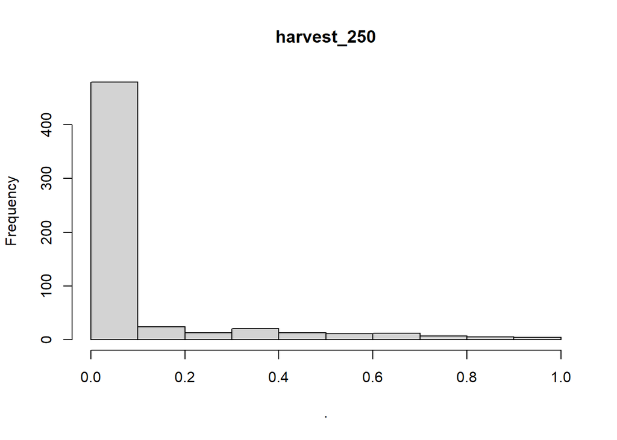

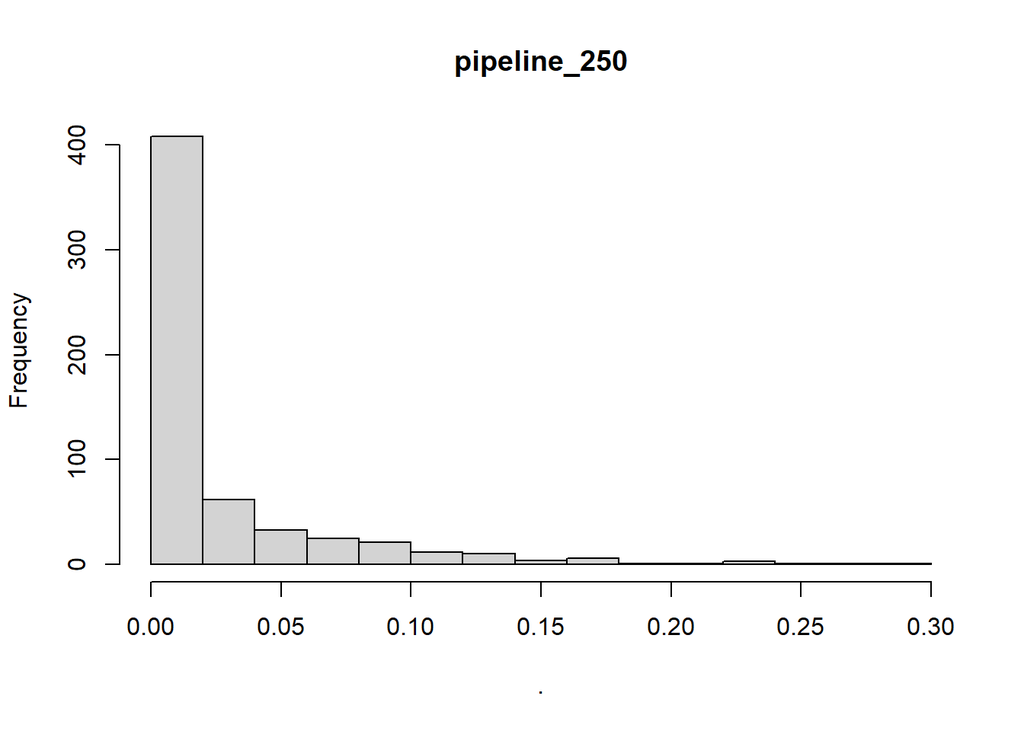

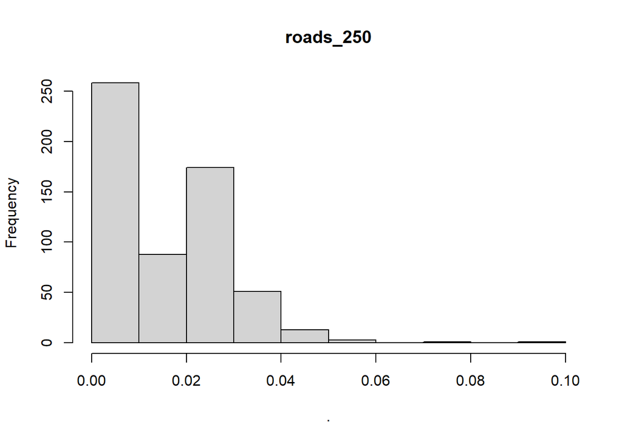

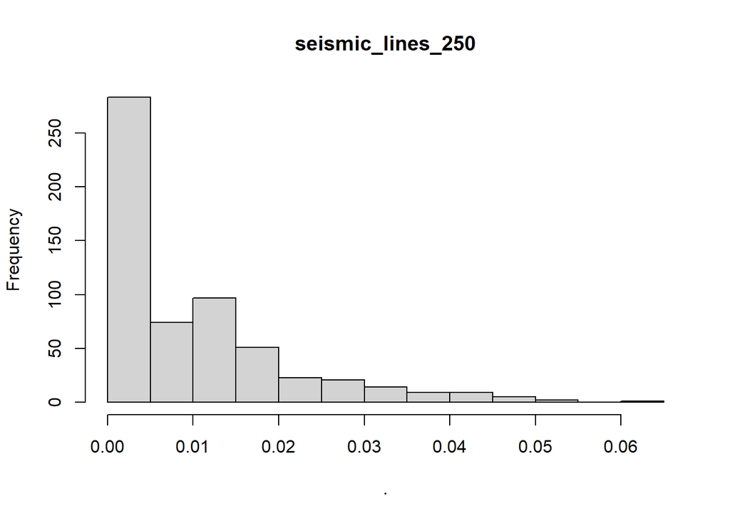

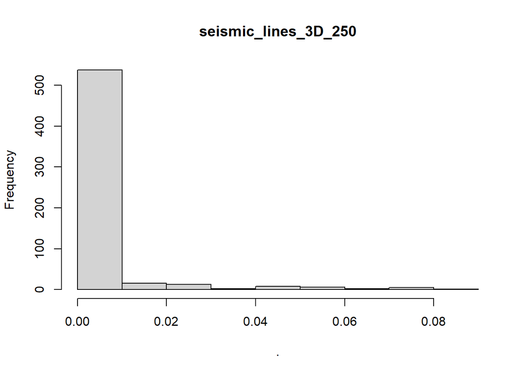

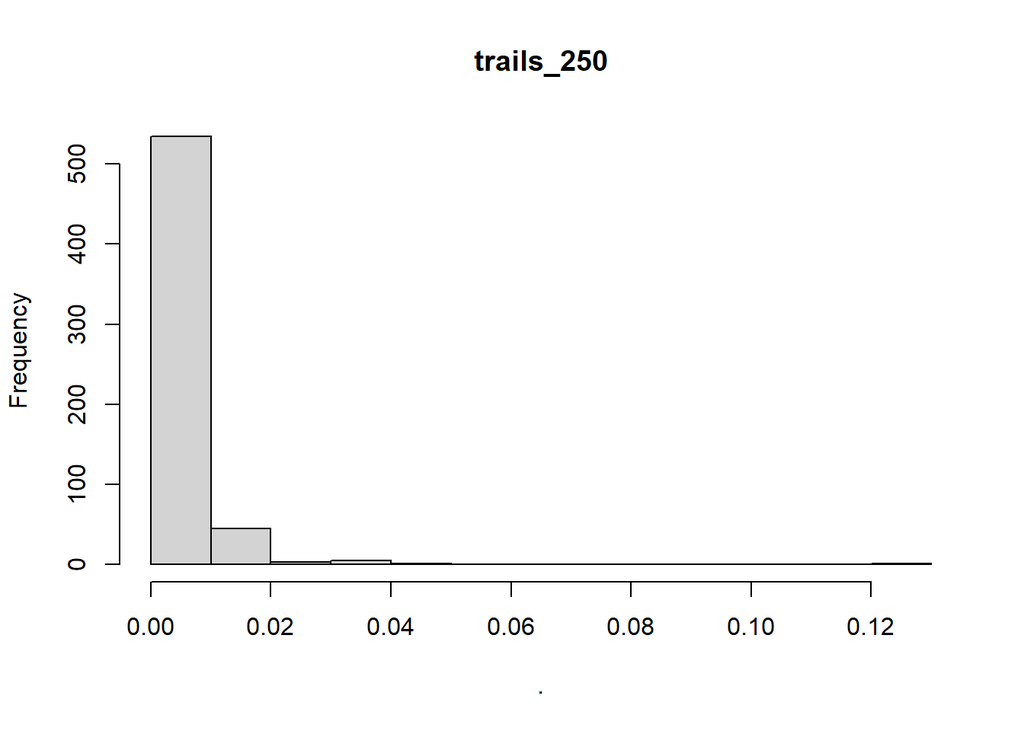

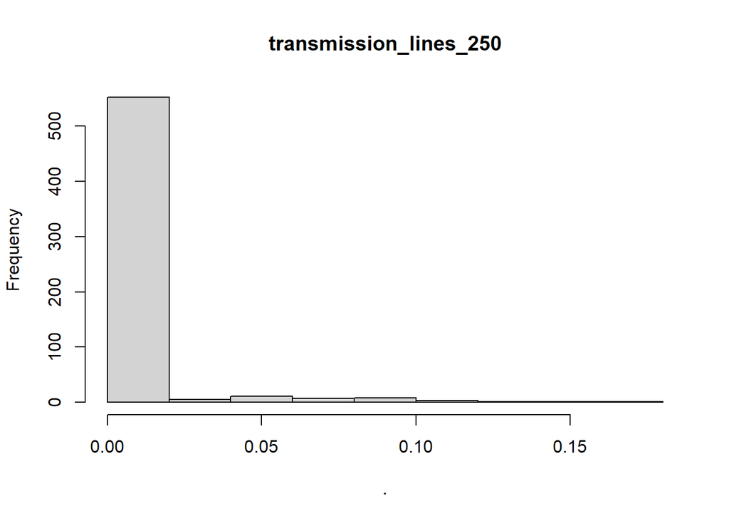

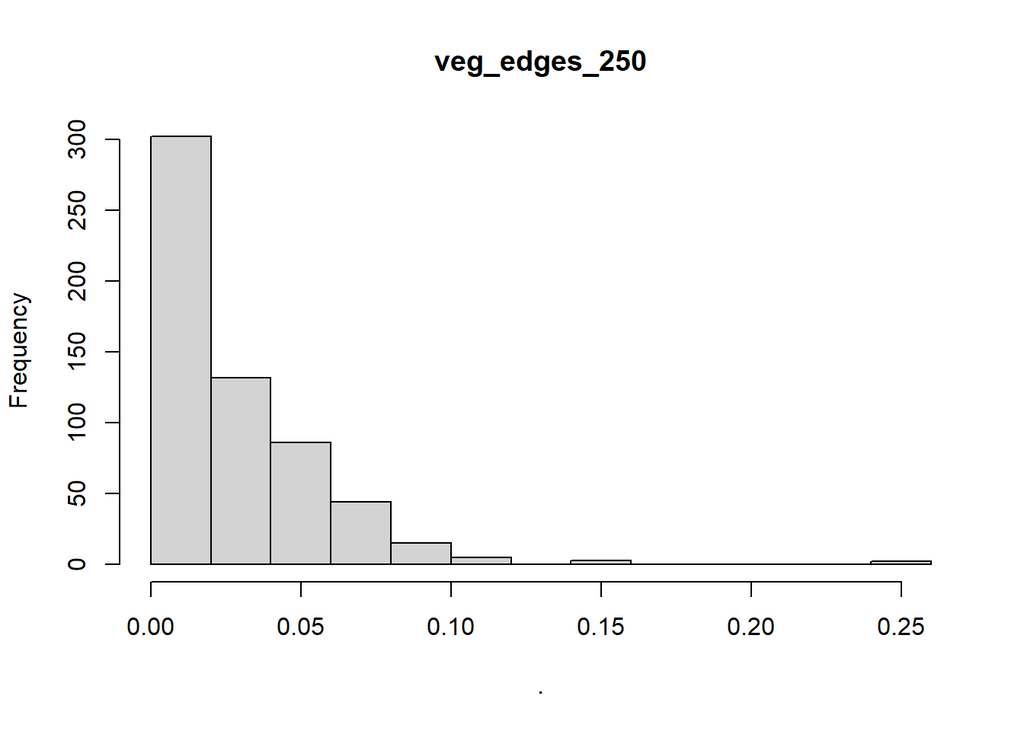

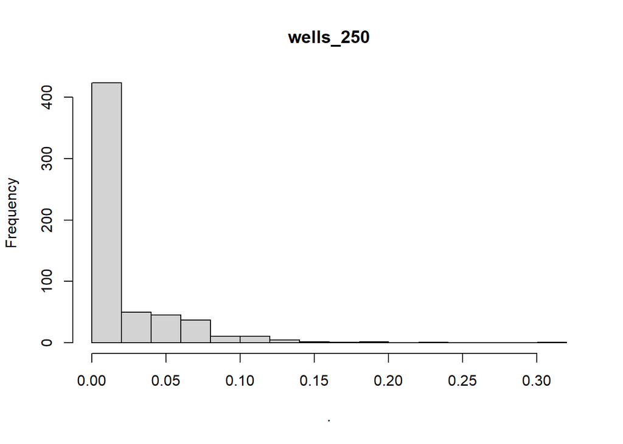

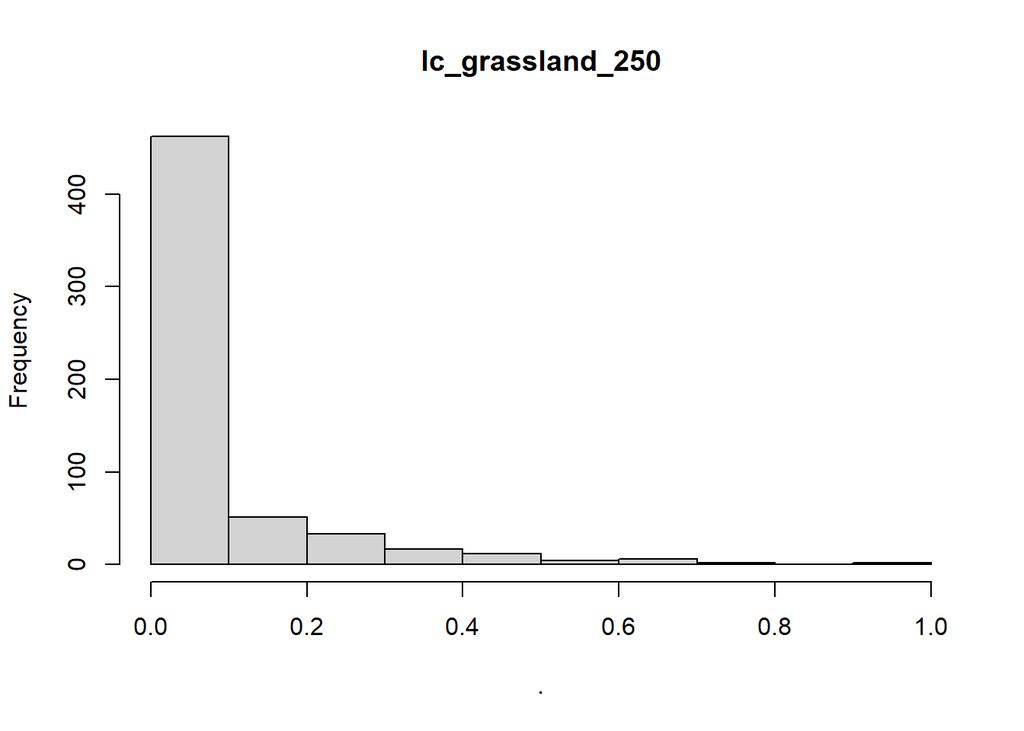

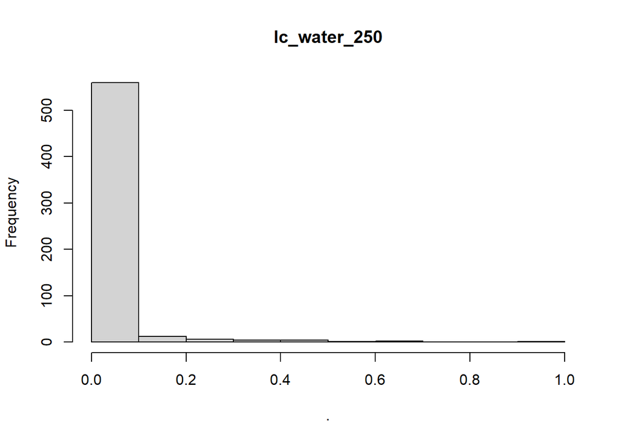

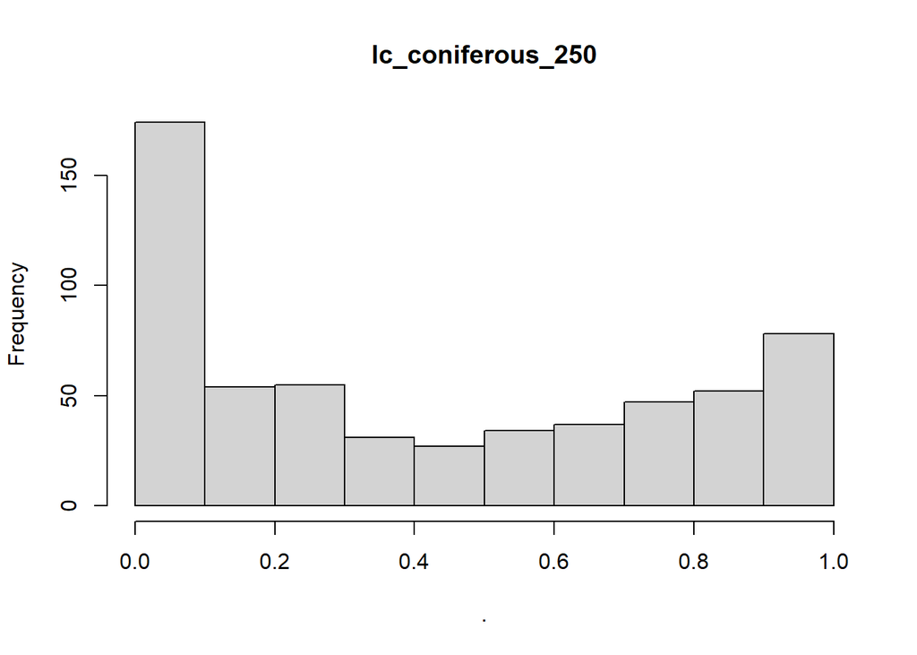

[7 more figures not shown]

[output not shown]

[output cut: 395 more lines]

```
## $density
##  [1] 2.886248 0.000000 0.000000 3.022071 0.000000 6.315789 4.719864 1.426146
##  [9] 0.000000 1.629881
##
## $mids
##  [1] 0.075 0.125 0.175 0.225 0.275 0.325 0.375 0.425 0.475 0.525
##
## $xname
## [1] "."
##
## $equidist
## [1] TRUE
##
## attr(,"class")
## [1] "histogram"
```

```r
# using purr solution
data %>%

  select(ends_with('_250')) %>%

  # use imap which will retain both the data (x) and the variable names (y)
  imap(~.x %>%

         # use the hist function on the data from previous pipe
        hist(.,

             # set the main title to y (each variable)
             main = .y))
```

> At 250 meters, it doesn’t look like we have much meaningful variation in:
> - Water (*lc_water_250*)
> - Transmission lines (*transmission_lines_250*)
> - Trails (*trails_250*)

> And some, but not a ton of, variation for:
> - 3D seismic lines (*seismic_lines_3D_250*)
> - Industrial sites (*osm_industrial_250*)

## 5.2. Histograms at 1000 m

Let’s repeat the exercise at 1000 m to give us a sense of how this might change with increasing scale:

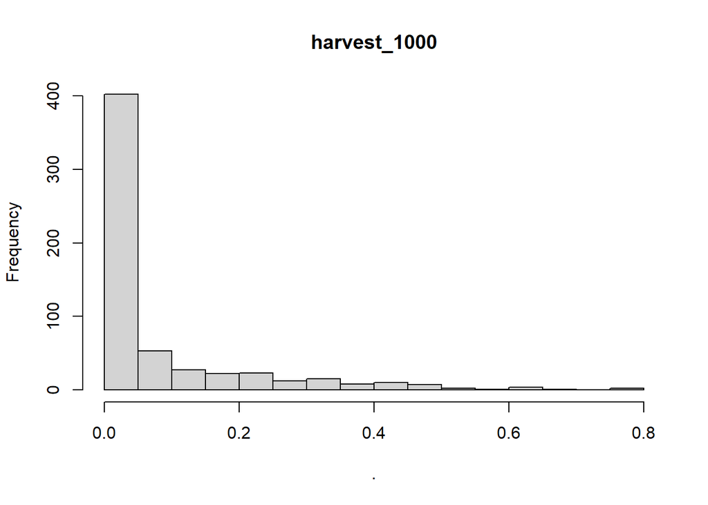

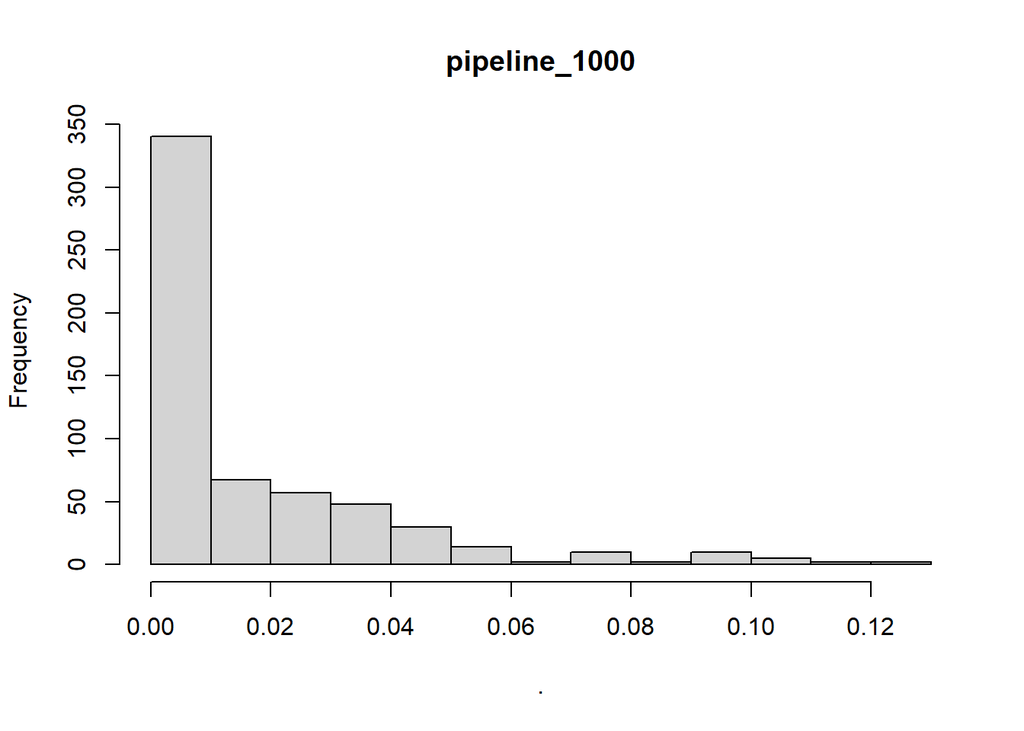

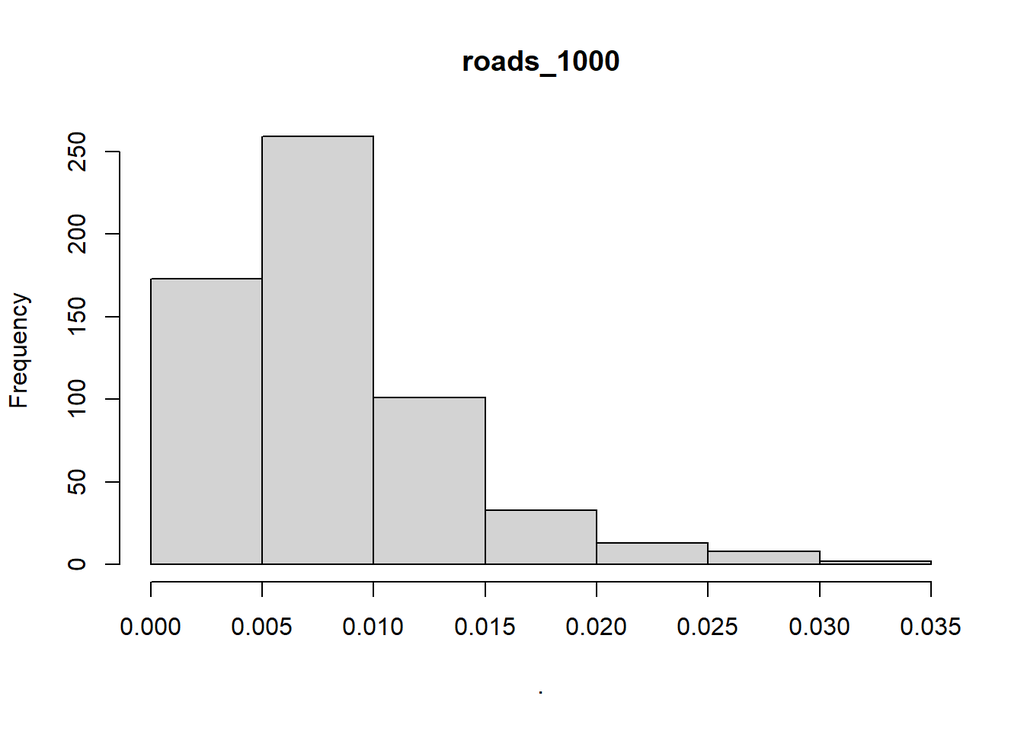

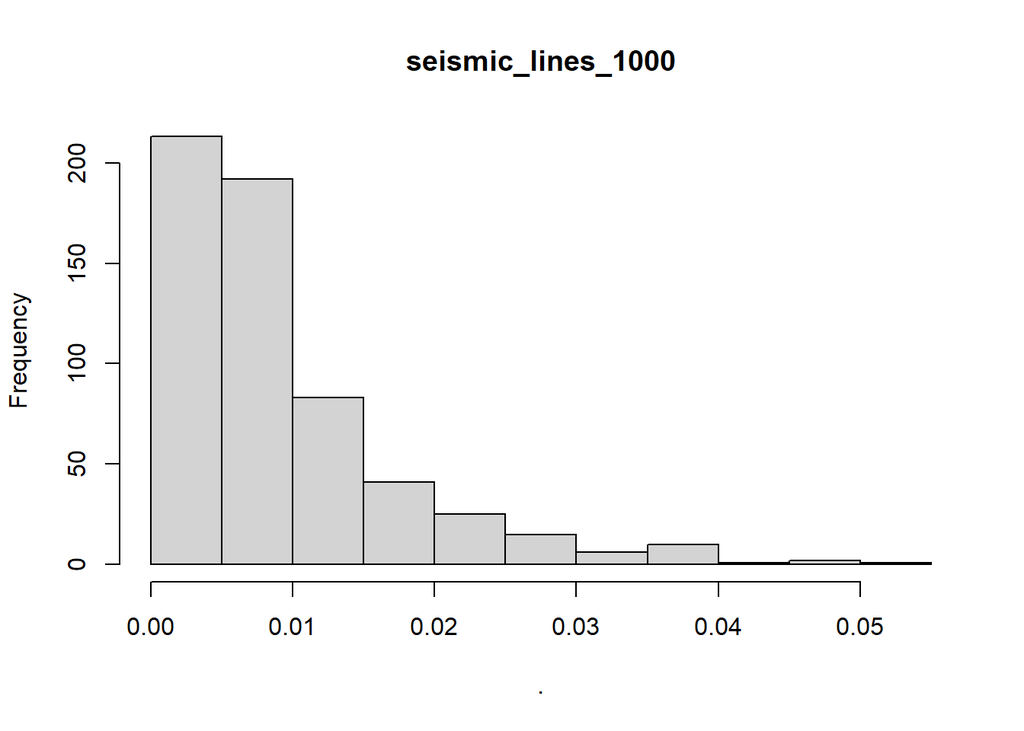

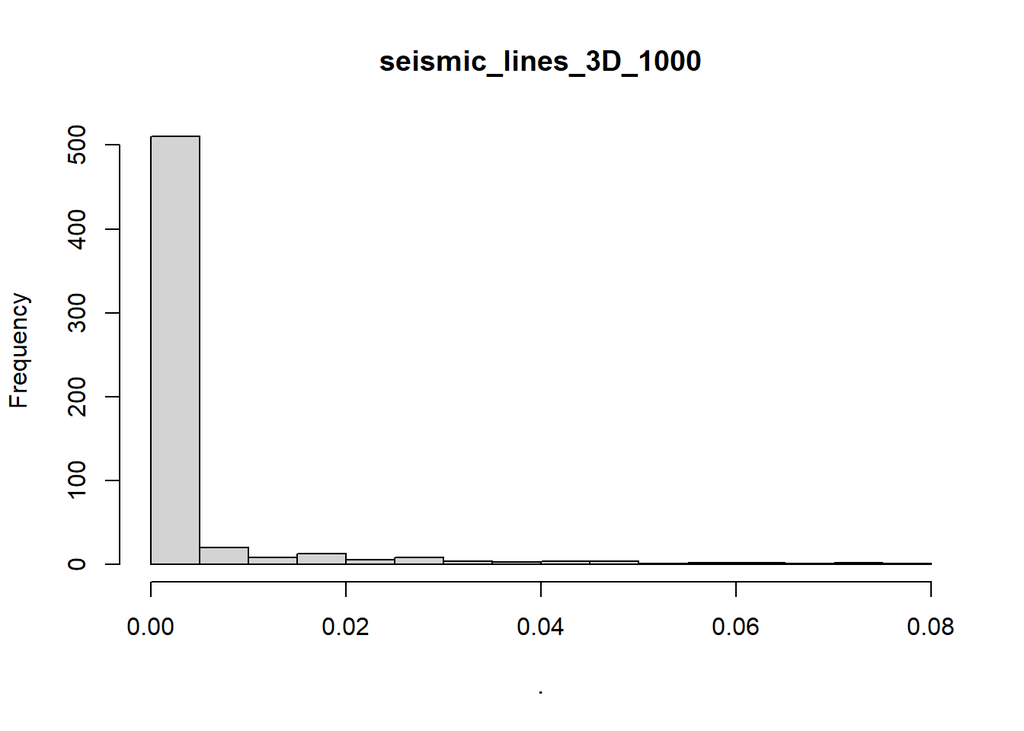

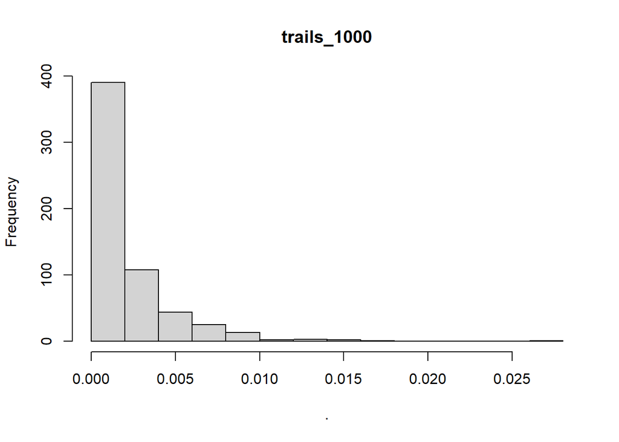

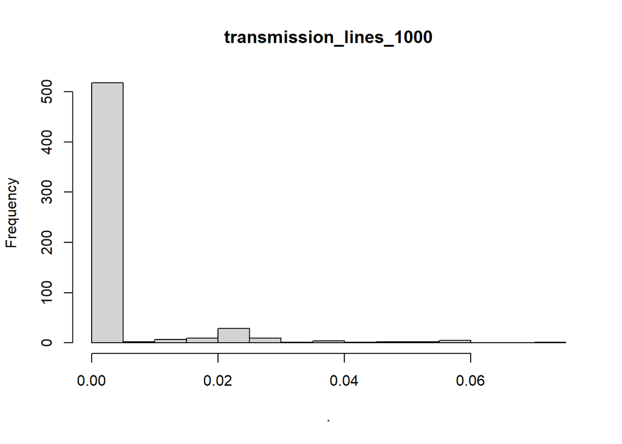

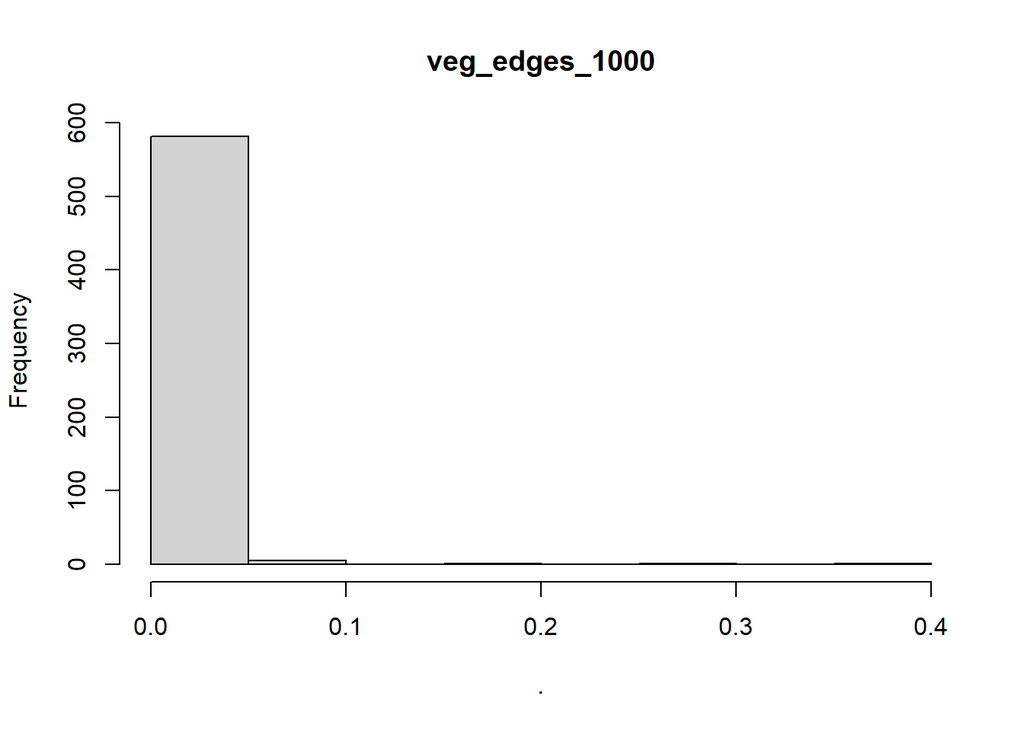

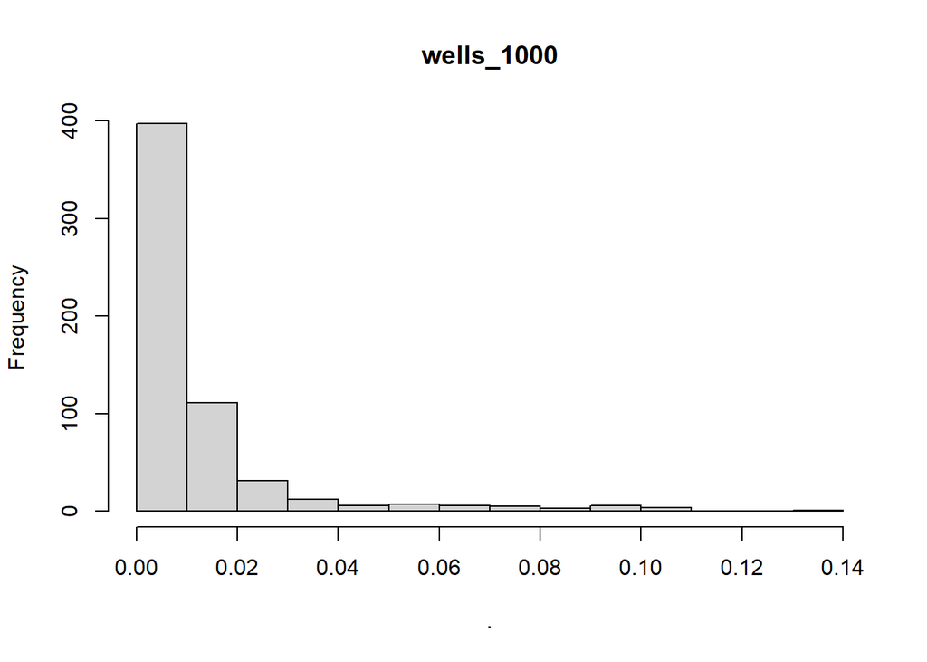

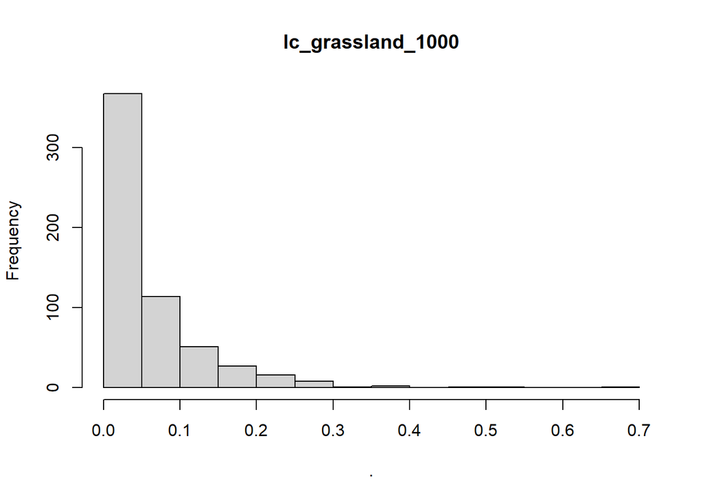

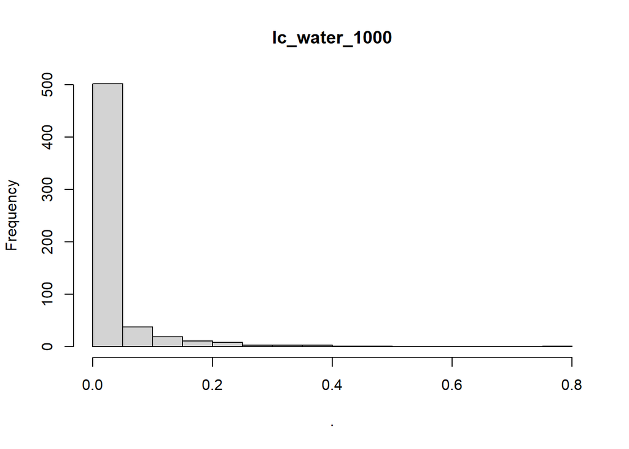

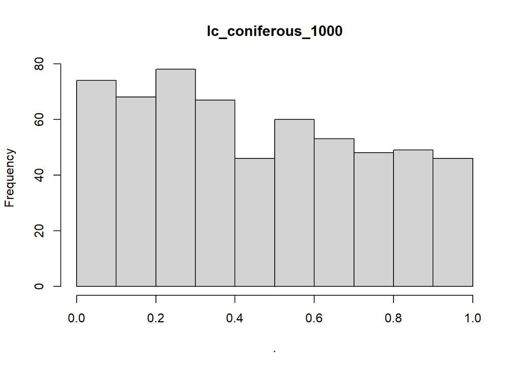

[7 more figures not shown]

[output not shown]

[output cut: 406 more lines]

```
## $density
##  [1]  7.215620  0.000000  0.000000  7.555178  0.000000  0.000000 12.478778
##  [8] 11.629881  3.480475  3.565365  0.000000  0.000000  0.000000  4.074703
##
## $mids
##  [1] 0.03 0.05 0.07 0.09 0.11 0.13 0.15 0.17 0.19 0.21 0.23 0.25 0.27 0.29
##
## $xname
## [1] "."
##
## $equidist
## [1] TRUE
##
## attr(,"class")
## [1] "histogram"
```

```r
# using purr solution
data %>%

  select(contains('_1000')) %>%

  # use imap which will retain both the data (x) and the variable names (y)
  imap(~.x %>%

         # use the hist function on the data from previous pipe
        hist(.,

             # set the main title to y (each variable)
             main = .y))
```

> At 1000 meters, it doesn’t look like we have much meaningful variation in:
> - Vegetated edges (*veg_edges_1000*)
> - Transmission lines (*transmission_lines_1000*)

> And some, but not a ton of, variation for:
> - 3D seismic lines (*seismic_lines_3D_1000*)
> - Water (*lc_water_1000*)
> - Industrial sites (*osm_industrial_1000*)